# Risk Factor Analysis

## Outcome Variable

**Outcome Variable:** haz

## Predictor Variables

**Intervention Variable:** hdlvry

**Adjustment Set:**

- arm
- sex
- W_mage
- meducyrs
- feducyrs
- hhwealth_quart
- single
- W_nrooms
- brthmon
- W_parity
- impsan
- delta_W_mage
- delta_meducyrs
- delta_feducyrs
- delta_hhwealth_quart
- delta_single
- delta_W_nrooms
- delta_brthmon
- delta_W_parity
- delta_impsan

## Stratifying Variables

The analysis was stratified on these variable(s):

- agecat
- studyid
- country

## Data Summary

| agecat | studyid | country | hdlvry | n_cell | n |
| --- | --- | --- | --- | --- | --- |
| Birth | ki1000108-CMC-V-BCS-2002 | INDIA | 0 | 92 | 92 |
| Birth | ki1000108-CMC-V-BCS-2002 | INDIA | 1 | 0 | 92 |
| Birth | ki1000108-IRC | INDIA | 0 | 381 | 388 |
| Birth | ki1000108-IRC | INDIA | 1 | 7 | 388 |
| Birth | ki1000109-EE | PAKISTAN | 0 | 161 | 238 |
| Birth | ki1000109-EE | PAKISTAN | 1 | 77 | 238 |
| Birth | ki1000304b-SAS-CompFeed | INDIA | 0 | 124 | 1085 |
| Birth | ki1000304b-SAS-CompFeed | INDIA | 1 | 961 | 1085 |
| Birth | ki1017093b-PROVIDE | BANGLADESH | 0 | 391 | 539 |
| Birth | ki1017093b-PROVIDE | BANGLADESH | 1 | 148 | 539 |
| Birth | ki1017093c-NIH-Crypto | BANGLADESH | 0 | 567 | 732 |
| Birth | ki1017093c-NIH-Crypto | BANGLADESH | 1 | 165 | 732 |
| Birth | ki1113344-GMS-Nepal | NEPAL | 0 | 157 | 646 |
| Birth | ki1113344-GMS-Nepal | NEPAL | 1 | 489 | 646 |
| Birth | ki1135781-COHORTS | INDIA | 0 | 2938 | 4694 |
| Birth | ki1135781-COHORTS | INDIA | 1 | 1756 | 4694 |
| Birth | kiGH5241-JiVitA-3 | BANGLADESH | 0 | 41 | 349 |
| Birth | kiGH5241-JiVitA-3 | BANGLADESH | 1 | 308 | 349 |
| Birth | kiGH5241-JiVitA-4 | BANGLADESH | 0 | 554 | 2808 |
| Birth | kiGH5241-JiVitA-4 | BANGLADESH | 1 | 2254 | 2808 |
| 6 months | ki1000108-CMC-V-BCS-2002 | INDIA | 0 | 358 | 366 |
| 6 months | ki1000108-CMC-V-BCS-2002 | INDIA | 1 | 8 | 366 |
| 6 months | ki1000108-IRC | INDIA | 0 | 399 | 407 |
| 6 months | ki1000108-IRC | INDIA | 1 | 8 | 407 |
| 6 months | ki1000109-EE | PAKISTAN | 0 | 250 | 371 |
| 6 months | ki1000109-EE | PAKISTAN | 1 | 121 | 371 |
| 6 months | ki1000304b-SAS-CompFeed | INDIA | 0 | 147 | 1091 |
| 6 months | ki1000304b-SAS-CompFeed | INDIA | 1 | 944 | 1091 |
| 6 months | ki1000304b-SAS-FoodSuppl | INDIA | 0 | 76 | 380 |
| 6 months | ki1000304b-SAS-FoodSuppl | INDIA | 1 | 304 | 380 |
| 6 months | ki1017093b-PROVIDE | BANGLADESH | 0 | 450 | 604 |
| 6 months | ki1017093b-PROVIDE | BANGLADESH | 1 | 154 | 604 |
| 6 months | ki1017093c-NIH-Crypto | BANGLADESH | 0 | 554 | 715 |
| 6 months | ki1017093c-NIH-Crypto | BANGLADESH | 1 | 161 | 715 |
| 6 months | ki1066203-TanzaniaChild2 | TANZANIA, UNITED REPUBLIC OF | 0 | 1889 | 1921 |
| 6 months | ki1066203-TanzaniaChild2 | TANZANIA, UNITED REPUBLIC OF | 1 | 32 | 1921 |
| 6 months | ki1113344-GMS-Nepal | NEPAL | 0 | 129 | 528 |
| 6 months | ki1113344-GMS-Nepal | NEPAL | 1 | 399 | 528 |
| 6 months | ki1135781-COHORTS | INDIA | 0 | 2900 | 4699 |
| 6 months | ki1135781-COHORTS | INDIA | 1 | 1799 | 4699 |
| 6 months | kiGH5241-JiVitA-3 | BANGLADESH | 0 | 39 | 332 |
| 6 months | kiGH5241-JiVitA-3 | BANGLADESH | 1 | 293 | 332 |
| 6 months | kiGH5241-JiVitA-4 | BANGLADESH | 0 | 1081 | 4038 |
| 6 months | kiGH5241-JiVitA-4 | BANGLADESH | 1 | 2957 | 4038 |
| 24 months | ki1000108-CMC-V-BCS-2002 | INDIA | 0 | 360 | 368 |
| 24 months | ki1000108-CMC-V-BCS-2002 | INDIA | 1 | 8 | 368 |
| 24 months | ki1000108-IRC | INDIA | 0 | 401 | 409 |
| 24 months | ki1000108-IRC | INDIA | 1 | 8 | 409 |
| 24 months | ki1000109-EE | PAKISTAN | 0 | 112 | 166 |
| 24 months | ki1000109-EE | PAKISTAN | 1 | 54 | 166 |
| 24 months | ki1017093b-PROVIDE | BANGLADESH | 0 | 433 | 578 |
| 24 months | ki1017093b-PROVIDE | BANGLADESH | 1 | 145 | 578 |
| 24 months | ki1017093c-NIH-Crypto | BANGLADESH | 0 | 391 | 514 |
| 24 months | ki1017093c-NIH-Crypto | BANGLADESH | 1 | 123 | 514 |
| 24 months | ki1066203-TanzaniaChild2 | TANZANIA, UNITED REPUBLIC OF | 0 | 6 | 6 |
| 24 months | ki1066203-TanzaniaChild2 | TANZANIA, UNITED REPUBLIC OF | 1 | 0 | 6 |
| 24 months | ki1113344-GMS-Nepal | NEPAL | 0 | 118 | 456 |
| 24 months | ki1113344-GMS-Nepal | NEPAL | 1 | 338 | 456 |
| 24 months | ki1135781-COHORTS | INDIA | 0 | 2233 | 3556 |
| 24 months | ki1135781-COHORTS | INDIA | 1 | 1323 | 3556 |
| 24 months | kiGH5241-JiVitA-3 | BANGLADESH | 0 | 35 | 291 |
| 24 months | kiGH5241-JiVitA-3 | BANGLADESH | 1 | 256 | 291 |
| 24 months | kiGH5241-JiVitA-4 | BANGLADESH | 0 | 1033 | 4005 |
| 24 months | kiGH5241-JiVitA-4 | BANGLADESH | 1 | 2972 | 4005 |

The following strata were considered:

- agecat: 24 months, studyid: ki1000108-CMC-V-BCS-2002, country: INDIA
- agecat: 24 months, studyid: ki1000108-IRC, country: INDIA
- agecat: 24 months, studyid: ki1000109-EE, country: PAKISTAN
- agecat: 24 months, studyid: ki1017093b-PROVIDE, country: BANGLADESH
- agecat: 24 months, studyid: ki1017093c-NIH-Crypto, country: BANGLADESH
- agecat: 24 months, studyid: ki1066203-TanzaniaChild2, country: TANZANIA, UNITED REPUBLIC OF
- agecat: 24 months, studyid: ki1113344-GMS-Nepal, country: NEPAL
- agecat: 24 months, studyid: ki1135781-COHORTS, country: INDIA
- agecat: 24 months, studyid: kiGH5241-JiVitA-3, country: BANGLADESH
- agecat: 24 months, studyid: kiGH5241-JiVitA-4, country: BANGLADESH
- agecat: 6 months, studyid: ki1000108-CMC-V-BCS-2002, country: INDIA
- agecat: 6 months, studyid: ki1000108-IRC, country: INDIA
- agecat: 6 months, studyid: ki1000109-EE, country: PAKISTAN
- agecat: 6 months, studyid: ki1000304b-SAS-CompFeed, country: INDIA
- agecat: 6 months, studyid: ki1000304b-SAS-FoodSuppl, country: INDIA
- agecat: 6 months, studyid: ki1017093b-PROVIDE, country: BANGLADESH
- agecat: 6 months, studyid: ki1017093c-NIH-Crypto, country: BANGLADESH
- agecat: 6 months, studyid: ki1066203-TanzaniaChild2, country: TANZANIA, UNITED REPUBLIC OF
- agecat: 6 months, studyid: ki1113344-GMS-Nepal, country: NEPAL
- agecat: 6 months, studyid: ki1135781-COHORTS, country: INDIA
- agecat: 6 months, studyid: kiGH5241-JiVitA-3, country: BANGLADESH
- agecat: 6 months, studyid: kiGH5241-JiVitA-4, country: BANGLADESH
- agecat: Birth, studyid: ki1000108-CMC-V-BCS-2002, country: INDIA
- agecat: Birth, studyid: ki1000108-IRC, country: INDIA
- agecat: Birth, studyid: ki1000109-EE, country: PAKISTAN
- agecat: Birth, studyid: ki1000304b-SAS-CompFeed, country: INDIA
- agecat: Birth, studyid: ki1017093b-PROVIDE, country: BANGLADESH
- agecat: Birth, studyid: ki1017093c-NIH-Crypto, country: BANGLADESH
- agecat: Birth, studyid: ki1113344-GMS-Nepal, country: NEPAL
- agecat: Birth, studyid: ki1135781-COHORTS, country: INDIA
- agecat: Birth, studyid: kiGH5241-JiVitA-3, country: BANGLADESH
- agecat: Birth, studyid: kiGH5241-JiVitA-4, country: BANGLADESH

### Dropped Strata

- agecat: Birth, studyid: ki1000108-CMC-V-BCS-2002, country: INDIA
- agecat: 24 months, studyid: ki1066203-TanzaniaChild2, country: TANZANIA, UNITED REPUBLIC OF

## Methods Detail

We’re interested in the causal parameters $E[Y_a]$ for all values of $a \in \mathcal{A}$. These parameters represent the mean outcome if, possibly contrary to fact, we intervened to set all units to have $A=a$. Under the randomization and positivity assumptions, these are identified by the statistical parameters $\psi_a=E_W[E_{Y|A,W}(Y|A=a,W)]$. In addition, we’re interested in the mean of $Y$, $E[Y]$ under no intervention (the observed mean). We will estimate these parameters by using SuperLearner to fit the relevant likelihood factors – $E_{Y|A,W}(Y|A=a,W)$ and $p(A=a|W)$, and then updating our likelihood fit using a joint TMLE.

For unadjusted analyses ($W=\{\}$), initial likelihoods were estimated using Lrnr_glm to estimate the simple $E(Y|A)$ and Lrnr_mean to estimate $p(A)$. For adjusted analyses, a small library containing Lrnr_glmnet, Lrnr_xgboost, and Lrnr_mean was used.

Having estimated these parameters, we will then use the delta method to estimate relative risks and attributable risks relative to a prespecified baseline level of $A$.

# Results Detail

## Results Plots

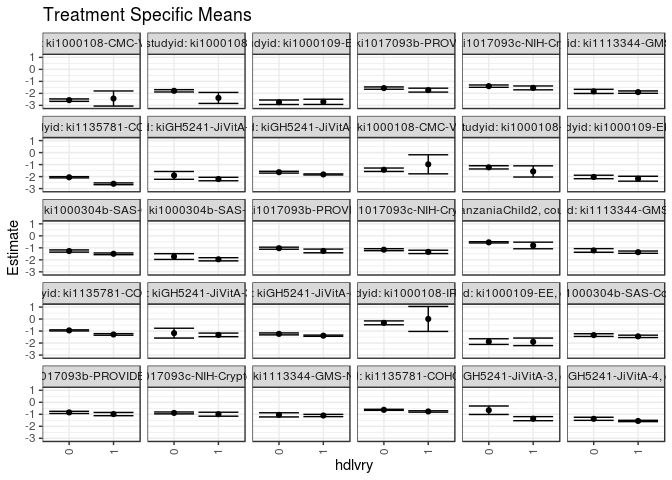

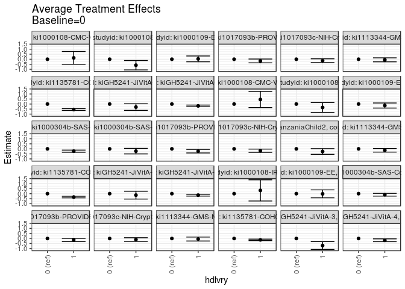

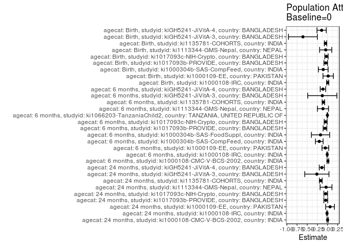

## Results Table

### Parameter: TSM

| agecat | studyid | country | intervention_level | baseline_level | estimate | ci_lower | ci_upper |
| --- | --- | --- | --- | --- | --- | --- | --- |
| Birth | ki1000108-IRC | INDIA | 0 | NA | -0.3138845 | -0.4765233 | -0.1512457 |
| Birth | ki1000108-IRC | INDIA | 1 | NA | 0.0100000 | -1.0310607 | 1.0510607 |
| Birth | ki1000109-EE | PAKISTAN | 0 | NA | -1.8786472 | -2.1152570 | -1.6420375 |
| Birth | ki1000109-EE | PAKISTAN | 1 | NA | -1.8975219 | -2.2118257 | -1.5832182 |
| Birth | ki1000304b-SAS-CompFeed | INDIA | 0 | NA | -1.3355847 | -1.4491182 | -1.2220512 |
| Birth | ki1000304b-SAS-CompFeed | INDIA | 1 | NA | -1.4405559 | -1.5412669 | -1.3398449 |
| Birth | ki1017093b-PROVIDE | BANGLADESH | 0 | NA | -0.8418160 | -0.9318983 | -0.7517337 |
| Birth | ki1017093b-PROVIDE | BANGLADESH | 1 | NA | -0.9819911 | -1.1163366 | -0.8476456 |
| Birth | ki1017093c-NIH-Crypto | BANGLADESH | 0 | NA | -0.8844836 | -0.9643918 | -0.8045755 |
| Birth | ki1017093c-NIH-Crypto | BANGLADESH | 1 | NA | -0.9923664 | -1.1577469 | -0.8269860 |
| Birth | ki1113344-GMS-Nepal | NEPAL | 0 | NA | -1.0467273 | -1.2202654 | -0.8731892 |
| Birth | ki1113344-GMS-Nepal | NEPAL | 1 | NA | -1.1014337 | -1.1959901 | -1.0068773 |
| Birth | ki1135781-COHORTS | INDIA | 0 | NA | -0.6268727 | -0.6715356 | -0.5822097 |
| Birth | ki1135781-COHORTS | INDIA | 1 | NA | -0.7643063 | -0.8235014 | -0.7051112 |
| Birth | kiGH5241-JiVitA-3 | BANGLADESH | 0 | NA | -0.6612525 | -1.0149203 | -0.3075848 |
| Birth | kiGH5241-JiVitA-3 | BANGLADESH | 1 | NA | -1.3644331 | -1.5339511 | -1.1949150 |
| Birth | kiGH5241-JiVitA-4 | BANGLADESH | 0 | NA | -1.3770615 | -1.5058341 | -1.2482889 |
| Birth | kiGH5241-JiVitA-4 | BANGLADESH | 1 | NA | -1.5559525 | -1.6107227 | -1.5011823 |
| 6 months | ki1000108-CMC-V-BCS-2002 | INDIA | 0 | NA | -1.4288687 | -1.5726614 | -1.2850760 |
| 6 months | ki1000108-CMC-V-BCS-2002 | INDIA | 1 | NA | -0.9754167 | -1.7693720 | -0.1814613 |
| 6 months | ki1000108-IRC | INDIA | 0 | NA | -1.2276901 | -1.3618868 | -1.0934933 |
| 6 months | ki1000108-IRC | INDIA | 1 | NA | -1.5693750 | -2.0379505 | -1.1007995 |
| 6 months | ki1000109-EE | PAKISTAN | 0 | NA | -2.0302237 | -2.1757418 | -1.8847055 |
| 6 months | ki1000109-EE | PAKISTAN | 1 | NA | -2.1769865 | -2.3822024 | -1.9717706 |
| 6 months | ki1000304b-SAS-CompFeed | INDIA | 0 | NA | -1.2673690 | -1.3591093 | -1.1756287 |
| 6 months | ki1000304b-SAS-CompFeed | INDIA | 1 | NA | -1.4981869 | -1.5697170 | -1.4266567 |
| 6 months | ki1000304b-SAS-FoodSuppl | INDIA | 0 | NA | -1.7272318 | -1.9677542 | -1.4867095 |
| 6 months | ki1000304b-SAS-FoodSuppl | INDIA | 1 | NA | -1.9552677 | -2.0869642 | -1.8235712 |
| 6 months | ki1017093b-PROVIDE | BANGLADESH | 0 | NA | -1.0299711 | -1.1159514 | -0.9439909 |
| 6 months | ki1017093b-PROVIDE | BANGLADESH | 1 | NA | -1.2595271 | -1.4137056 | -1.1053486 |
| 6 months | ki1017093c-NIH-Crypto | BANGLADESH | 0 | NA | -1.1532714 | -1.2361403 | -1.0704026 |
| 6 months | ki1017093c-NIH-Crypto | BANGLADESH | 1 | NA | -1.3378720 | -1.4762155 | -1.1995286 |
| 6 months | ki1066203-TanzaniaChild2 | TANZANIA, UNITED REPUBLIC OF | 0 | NA | -0.5418295 | -0.5931733 | -0.4904857 |
| 6 months | ki1066203-TanzaniaChild2 | TANZANIA, UNITED REPUBLIC OF | 1 | NA | -0.8035468 | -1.0790402 | -0.5280535 |
| 6 months | ki1113344-GMS-Nepal | NEPAL | 0 | NA | -1.2175689 | -1.3691932 | -1.0659446 |
| 6 months | ki1113344-GMS-Nepal | NEPAL | 1 | NA | -1.3621925 | -1.4560896 | -1.2682954 |
| 6 months | ki1135781-COHORTS | INDIA | 0 | NA | -0.9454832 | -0.9906063 | -0.9003601 |
| 6 months | ki1135781-COHORTS | INDIA | 1 | NA | -1.2823624 | -1.3481143 | -1.2166106 |
| 6 months | kiGH5241-JiVitA-3 | BANGLADESH | 0 | NA | -1.1732916 | -1.5843388 | -0.7622443 |
| 6 months | kiGH5241-JiVitA-3 | BANGLADESH | 1 | NA | -1.3192317 | -1.4670318 | -1.1714316 |
| 6 months | kiGH5241-JiVitA-4 | BANGLADESH | 0 | NA | -1.2357648 | -1.3160738 | -1.1554558 |
| 6 months | kiGH5241-JiVitA-4 | BANGLADESH | 1 | NA | -1.3844378 | -1.4334477 | -1.3354279 |
| 24 months | ki1000108-CMC-V-BCS-2002 | INDIA | 0 | NA | -2.5640139 | -2.6645275 | -2.4635003 |
| 24 months | ki1000108-CMC-V-BCS-2002 | INDIA | 1 | NA | -2.4300000 | -3.0592261 | -1.8007739 |
| 24 months | ki1000108-IRC | INDIA | 0 | NA | -1.7871446 | -1.8820825 | -1.6922068 |
| 24 months | ki1000108-IRC | INDIA | 1 | NA | -2.3818750 | -2.8405973 | -1.9231527 |
| 24 months | ki1000109-EE | PAKISTAN | 0 | NA | -2.7404000 | -2.9285667 | -2.5522333 |
| 24 months | ki1000109-EE | PAKISTAN | 1 | NA | -2.7054667 | -2.9225730 | -2.4883605 |
| 24 months | ki1017093b-PROVIDE | BANGLADESH | 0 | NA | -1.5605203 | -1.6572838 | -1.4637567 |
| 24 months | ki1017093b-PROVIDE | BANGLADESH | 1 | NA | -1.7303389 | -1.8937360 | -1.5669418 |
| 24 months | ki1017093c-NIH-Crypto | BANGLADESH | 0 | NA | -1.3974176 | -1.4945671 | -1.3002681 |
| 24 months | ki1017093c-NIH-Crypto | BANGLADESH | 1 | NA | -1.5431550 | -1.7038519 | -1.3824581 |
| 24 months | ki1113344-GMS-Nepal | NEPAL | 0 | NA | -1.8360631 | -2.0085958 | -1.6635303 |
| 24 months | ki1113344-GMS-Nepal | NEPAL | 1 | NA | -1.8961872 | -1.9951378 | -1.7972367 |
| 24 months | ki1135781-COHORTS | INDIA | 0 | NA | -2.0568050 | -2.1077626 | -2.0058473 |
| 24 months | ki1135781-COHORTS | INDIA | 1 | NA | -2.5991071 | -2.6721842 | -2.5260300 |
| 24 months | kiGH5241-JiVitA-3 | BANGLADESH | 0 | NA | -1.9008226 | -2.2258401 | -1.5758050 |
| 24 months | kiGH5241-JiVitA-3 | BANGLADESH | 1 | NA | -2.2034695 | -2.3471804 | -2.0597587 |
| 24 months | kiGH5241-JiVitA-4 | BANGLADESH | 0 | NA | -1.6329634 | -1.7066330 | -1.5592939 |
| 24 months | kiGH5241-JiVitA-4 | BANGLADESH | 1 | NA | -1.8186832 | -1.8620390 | -1.7753274 |

### Parameter: E(Y)

| agecat | studyid | country | intervention_level | baseline_level | estimate | ci_lower | ci_upper |
| --- | --- | --- | --- | --- | --- | --- | --- |
| Birth | ki1000108-IRC | INDIA | NA | NA | -0.3080412 | -0.4687931 | -0.1472894 |
| Birth | ki1000109-EE | PAKISTAN | NA | NA | -1.8614286 | -2.0501173 | -1.6727398 |
| Birth | ki1000304b-SAS-CompFeed | INDIA | NA | NA | -1.4401843 | -1.5334809 | -1.3468878 |
| Birth | ki1017093b-PROVIDE | BANGLADESH | NA | NA | -0.8851020 | -0.9601332 | -0.8100709 |
| Birth | ki1017093c-NIH-Crypto | BANGLADESH | NA | NA | -0.9094945 | -0.9809370 | -0.8380521 |
| Birth | ki1113344-GMS-Nepal | NEPAL | NA | NA | -1.0909443 | -1.1734385 | -1.0084500 |
| Birth | ki1135781-COHORTS | INDIA | NA | NA | -0.6762420 | -0.7093108 | -0.6431732 |
| Birth | kiGH5241-JiVitA-3 | BANGLADESH | NA | NA | -1.2665330 | -1.4233277 | -1.1097382 |
| Birth | kiGH5241-JiVitA-4 | BANGLADESH | NA | NA | -1.5216453 | -1.5715117 | -1.4717789 |
| 6 months | ki1000108-CMC-V-BCS-2002 | INDIA | NA | NA | -1.4189572 | -1.5607165 | -1.2771979 |
| 6 months | ki1000108-IRC | INDIA | NA | NA | -1.2344062 | -1.3658524 | -1.1029600 |
| 6 months | ki1000109-EE | PAKISTAN | NA | NA | -2.0826460 | -2.2022514 | -1.9630406 |
| 6 months | ki1000304b-SAS-CompFeed | INDIA | NA | NA | -1.4699588 | -1.5446559 | -1.3952616 |
| 6 months | ki1000304b-SAS-FoodSuppl | INDIA | NA | NA | -1.8986842 | -2.0118892 | -1.7854792 |
| 6 months | ki1017093b-PROVIDE | BANGLADESH | NA | NA | -1.0916915 | -1.1661176 | -1.0172654 |
| 6 months | ki1017093c-NIH-Crypto | BANGLADESH | NA | NA | -1.1986783 | -1.2700937 | -1.1272630 |
| 6 months | ki1066203-TanzaniaChild2 | TANZANIA, UNITED REPUBLIC OF | NA | NA | -0.5440573 | -0.5945614 | -0.4935533 |
| 6 months | ki1113344-GMS-Nepal | NEPAL | NA | NA | -1.3296275 | -1.4093037 | -1.2499514 |
| 6 months | ki1135781-COHORTS | INDIA | NA | NA | -1.0458076 | -1.0793244 | -1.0122908 |
| 6 months | kiGH5241-JiVitA-3 | BANGLADESH | NA | NA | -1.3017169 | -1.4476325 | -1.1558012 |
| 6 months | kiGH5241-JiVitA-4 | BANGLADESH | NA | NA | -1.3481303 | -1.3904710 | -1.3057895 |
| 24 months | ki1000108-CMC-V-BCS-2002 | INDIA | NA | NA | -2.5611005 | -2.6603759 | -2.4618252 |
| 24 months | ki1000108-IRC | INDIA | NA | NA | -1.7987775 | -1.8923914 | -1.7051636 |
| 24 months | ki1000109-EE | PAKISTAN | NA | NA | -2.6770382 | -2.8210532 | -2.5330231 |
| 24 months | ki1017093b-PROVIDE | BANGLADESH | NA | NA | -1.6024221 | -1.6857420 | -1.5191023 |
| 24 months | ki1017093c-NIH-Crypto | BANGLADESH | NA | NA | -1.4412646 | -1.5249156 | -1.3576135 |
| 24 months | ki1113344-GMS-Nepal | NEPAL | NA | NA | -1.8717982 | -1.9591776 | -1.7844189 |
| 24 months | ki1135781-COHORTS | INDIA | NA | NA | -2.2218335 | -2.2619519 | -2.1817151 |
| 24 months | kiGH5241-JiVitA-3 | BANGLADESH | NA | NA | -2.1628866 | -2.3052995 | -2.0204737 |
| 24 months | kiGH5241-JiVitA-4 | BANGLADESH | NA | NA | -1.7725918 | -1.8111207 | -1.7340629 |

### Parameter: ATE

| agecat | studyid | country | intervention_level | baseline_level | estimate | ci_lower | ci_upper |
| --- | --- | --- | --- | --- | --- | --- | --- |
| Birth | ki1000108-IRC | INDIA | 0 | 0 | 0.0000000 | 0.0000000 | 0.0000000 |
| Birth | ki1000108-IRC | INDIA | 1 | 0 | 0.3238845 | -0.7298036 | 1.3775727 |
| Birth | ki1000109-EE | PAKISTAN | 0 | 0 | 0.0000000 | 0.0000000 | 0.0000000 |
| Birth | ki1000109-EE | PAKISTAN | 1 | 0 | -0.0188747 | -0.4139557 | 0.3762064 |
| Birth | ki1000304b-SAS-CompFeed | INDIA | 0 | 0 | 0.0000000 | 0.0000000 | 0.0000000 |
| Birth | ki1000304b-SAS-CompFeed | INDIA | 1 | 0 | -0.1049712 | -0.2421812 | 0.0322387 |
| Birth | ki1017093b-PROVIDE | BANGLADESH | 0 | 0 | 0.0000000 | 0.0000000 | 0.0000000 |
| Birth | ki1017093b-PROVIDE | BANGLADESH | 1 | 0 | -0.1401751 | -0.3019136 | 0.0215634 |
| Birth | ki1017093c-NIH-Crypto | BANGLADESH | 0 | 0 | 0.0000000 | 0.0000000 | 0.0000000 |
| Birth | ki1017093c-NIH-Crypto | BANGLADESH | 1 | 0 | -0.1078828 | -0.2923423 | 0.0765768 |
| Birth | ki1113344-GMS-Nepal | NEPAL | 0 | 0 | 0.0000000 | 0.0000000 | 0.0000000 |
| Birth | ki1113344-GMS-Nepal | NEPAL | 1 | 0 | -0.0547064 | -0.2505821 | 0.1411693 |
| Birth | ki1135781-COHORTS | INDIA | 0 | 0 | 0.0000000 | 0.0000000 | 0.0000000 |
| Birth | ki1135781-COHORTS | INDIA | 1 | 0 | -0.1374336 | -0.2113885 | -0.0634787 |
| Birth | kiGH5241-JiVitA-3 | BANGLADESH | 0 | 0 | 0.0000000 | 0.0000000 | 0.0000000 |
| Birth | kiGH5241-JiVitA-3 | BANGLADESH | 1 | 0 | -0.7031805 | -1.0962562 | -0.3101049 |
| Birth | kiGH5241-JiVitA-4 | BANGLADESH | 0 | 0 | 0.0000000 | 0.0000000 | 0.0000000 |
| Birth | kiGH5241-JiVitA-4 | BANGLADESH | 1 | 0 | -0.1788910 | -0.3196027 | -0.0381793 |
| 6 months | ki1000108-CMC-V-BCS-2002 | INDIA | 0 | 0 | 0.0000000 | 0.0000000 | 0.0000000 |
| 6 months | ki1000108-CMC-V-BCS-2002 | INDIA | 1 | 0 | 0.4534520 | -0.3534193 | 1.2603234 |
| 6 months | ki1000108-IRC | INDIA | 0 | 0 | 0.0000000 | 0.0000000 | 0.0000000 |
| 6 months | ki1000108-IRC | INDIA | 1 | 0 | -0.3416849 | -0.8290982 | 0.1457284 |
| 6 months | ki1000109-EE | PAKISTAN | 0 | 0 | 0.0000000 | 0.0000000 | 0.0000000 |
| 6 months | ki1000109-EE | PAKISTAN | 1 | 0 | -0.1467628 | -0.3987959 | 0.1052703 |
| 6 months | ki1000304b-SAS-CompFeed | INDIA | 0 | 0 | 0.0000000 | 0.0000000 | 0.0000000 |
| 6 months | ki1000304b-SAS-CompFeed | INDIA | 1 | 0 | -0.2308179 | -0.3388002 | -0.1228355 |
| 6 months | ki1000304b-SAS-FoodSuppl | INDIA | 0 | 0 | 0.0000000 | 0.0000000 | 0.0000000 |
| 6 months | ki1000304b-SAS-FoodSuppl | INDIA | 1 | 0 | -0.2280359 | -0.5027127 | 0.0466410 |
| 6 months | ki1017093b-PROVIDE | BANGLADESH | 0 | 0 | 0.0000000 | 0.0000000 | 0.0000000 |
| 6 months | ki1017093b-PROVIDE | BANGLADESH | 1 | 0 | -0.2295560 | -0.4063291 | -0.0527828 |
| 6 months | ki1017093c-NIH-Crypto | BANGLADESH | 0 | 0 | 0.0000000 | 0.0000000 | 0.0000000 |
| 6 months | ki1017093c-NIH-Crypto | BANGLADESH | 1 | 0 | -0.1846006 | -0.3459333 | -0.0232680 |
| 6 months | ki1066203-TanzaniaChild2 | TANZANIA, UNITED REPUBLIC OF | 0 | 0 | 0.0000000 | 0.0000000 | 0.0000000 |
| 6 months | ki1066203-TanzaniaChild2 | TANZANIA, UNITED REPUBLIC OF | 1 | 0 | -0.2617174 | -0.5420399 | 0.0186052 |
| 6 months | ki1113344-GMS-Nepal | NEPAL | 0 | 0 | 0.0000000 | 0.0000000 | 0.0000000 |
| 6 months | ki1113344-GMS-Nepal | NEPAL | 1 | 0 | -0.1446236 | -0.3236633 | 0.0344161 |
| 6 months | ki1135781-COHORTS | INDIA | 0 | 0 | 0.0000000 | 0.0000000 | 0.0000000 |
| 6 months | ki1135781-COHORTS | INDIA | 1 | 0 | -0.3368793 | -0.4162984 | -0.2574602 |
| 6 months | kiGH5241-JiVitA-3 | BANGLADESH | 0 | 0 | 0.0000000 | 0.0000000 | 0.0000000 |
| 6 months | kiGH5241-JiVitA-3 | BANGLADESH | 1 | 0 | -0.1459401 | -0.5361340 | 0.2442537 |
| 6 months | kiGH5241-JiVitA-4 | BANGLADESH | 0 | 0 | 0.0000000 | 0.0000000 | 0.0000000 |
| 6 months | kiGH5241-JiVitA-4 | BANGLADESH | 1 | 0 | -0.1486730 | -0.2394208 | -0.0579251 |
| 24 months | ki1000108-CMC-V-BCS-2002 | INDIA | 0 | 0 | 0.0000000 | 0.0000000 | 0.0000000 |
| 24 months | ki1000108-CMC-V-BCS-2002 | INDIA | 1 | 0 | 0.1340139 | -0.5031898 | 0.7712175 |
| 24 months | ki1000108-IRC | INDIA | 0 | 0 | 0.0000000 | 0.0000000 | 0.0000000 |
| 24 months | ki1000108-IRC | INDIA | 1 | 0 | -0.5947304 | -1.0631739 | -0.1262869 |
| 24 months | ki1000109-EE | PAKISTAN | 0 | 0 | 0.0000000 | 0.0000000 | 0.0000000 |
| 24 months | ki1000109-EE | PAKISTAN | 1 | 0 | 0.0349333 | -0.2549488 | 0.3248154 |
| 24 months | ki1017093b-PROVIDE | BANGLADESH | 0 | 0 | 0.0000000 | 0.0000000 | 0.0000000 |
| 24 months | ki1017093b-PROVIDE | BANGLADESH | 1 | 0 | -0.1698186 | -0.3598078 | 0.0201705 |
| 24 months | ki1017093c-NIH-Crypto | BANGLADESH | 0 | 0 | 0.0000000 | 0.0000000 | 0.0000000 |
| 24 months | ki1017093c-NIH-Crypto | BANGLADESH | 1 | 0 | -0.1457374 | -0.3335721 | 0.0420974 |
| 24 months | ki1113344-GMS-Nepal | NEPAL | 0 | 0 | 0.0000000 | 0.0000000 | 0.0000000 |
| 24 months | ki1113344-GMS-Nepal | NEPAL | 1 | 0 | -0.0601242 | -0.2588306 | 0.1385822 |
| 24 months | ki1135781-COHORTS | INDIA | 0 | 0 | 0.0000000 | 0.0000000 | 0.0000000 |
| 24 months | ki1135781-COHORTS | INDIA | 1 | 0 | -0.5423021 | -0.6321825 | -0.4524217 |
| 24 months | kiGH5241-JiVitA-3 | BANGLADESH | 0 | 0 | 0.0000000 | 0.0000000 | 0.0000000 |
| 24 months | kiGH5241-JiVitA-3 | BANGLADESH | 1 | 0 | -0.3026470 | -0.6321601 | 0.0268661 |
| 24 months | kiGH5241-JiVitA-4 | BANGLADESH | 0 | 0 | 0.0000000 | 0.0000000 | 0.0000000 |
| 24 months | kiGH5241-JiVitA-4 | BANGLADESH | 1 | 0 | -0.1857197 | -0.2684583 | -0.1029812 |

### Parameter: PAR

| agecat | studyid | country | intervention_level | baseline_level | estimate | ci_lower | ci_upper |
| --- | --- | --- | --- | --- | --- | --- | --- |
| Birth | ki1000108-IRC | INDIA | 0 | NA | 0.0058433 | -0.0208468 | 0.0325333 |
| Birth | ki1000109-EE | PAKISTAN | 0 | NA | 0.0172187 | -0.1107612 | 0.1451985 |
| Birth | ki1000304b-SAS-CompFeed | INDIA | 0 | NA | -0.1045997 | -0.2249930 | 0.0157936 |
| Birth | ki1017093b-PROVIDE | BANGLADESH | 0 | NA | -0.0432861 | -0.0880235 | 0.0014514 |
| Birth | ki1017093c-NIH-Crypto | BANGLADESH | 0 | NA | -0.0250109 | -0.0662469 | 0.0162251 |
| Birth | ki1113344-GMS-Nepal | NEPAL | 0 | NA | -0.0442170 | -0.1937990 | 0.1053651 |
| Birth | ki1135781-COHORTS | INDIA | 0 | NA | -0.0493693 | -0.0779861 | -0.0207526 |
| Birth | kiGH5241-JiVitA-3 | BANGLADESH | 0 | NA | -0.6052804 | -0.9599988 | -0.2505620 |
| Birth | kiGH5241-JiVitA-4 | BANGLADESH | 0 | NA | -0.1445838 | -0.2589950 | -0.0301726 |
| 6 months | ki1000108-CMC-V-BCS-2002 | INDIA | 0 | NA | 0.0099115 | -0.0113762 | 0.0311993 |
| 6 months | ki1000108-IRC | INDIA | 0 | NA | -0.0067162 | -0.0197457 | 0.0063134 |
| 6 months | ki1000109-EE | PAKISTAN | 0 | NA | -0.0524223 | -0.1355901 | 0.0307454 |
| 6 months | ki1000304b-SAS-CompFeed | INDIA | 0 | NA | -0.2025898 | -0.2977890 | -0.1073906 |
| 6 months | ki1000304b-SAS-FoodSuppl | INDIA | 0 | NA | -0.1714524 | -0.3961150 | 0.0532102 |
| 6 months | ki1017093b-PROVIDE | BANGLADESH | 0 | NA | -0.0617204 | -0.1065444 | -0.0168964 |
| 6 months | ki1017093c-NIH-Crypto | BANGLADESH | 0 | NA | -0.0454069 | -0.0820948 | -0.0087190 |
| 6 months | ki1066203-TanzaniaChild2 | TANZANIA, UNITED REPUBLIC OF | 0 | NA | -0.0022279 | -0.0093186 | 0.0048628 |
| 6 months | ki1113344-GMS-Nepal | NEPAL | 0 | NA | -0.1120586 | -0.2494815 | 0.0253642 |
| 6 months | ki1135781-COHORTS | INDIA | 0 | NA | -0.1003244 | -0.1307332 | -0.0699157 |
| 6 months | kiGH5241-JiVitA-3 | BANGLADESH | 0 | NA | -0.1284253 | -0.4874656 | 0.2306150 |
| 6 months | kiGH5241-JiVitA-4 | BANGLADESH | 0 | NA | -0.1123654 | -0.1788736 | -0.0458573 |
| 24 months | ki1000108-CMC-V-BCS-2002 | INDIA | 0 | NA | 0.0029133 | -0.0131417 | 0.0189684 |
| 24 months | ki1000108-IRC | INDIA | 0 | NA | -0.0116329 | -0.0258108 | 0.0025451 |
| 24 months | ki1000109-EE | PAKISTAN | 0 | NA | 0.0633619 | -0.0447862 | 0.1715099 |
| 24 months | ki1017093b-PROVIDE | BANGLADESH | 0 | NA | -0.0419019 | -0.0895567 | 0.0057530 |
| 24 months | ki1017093c-NIH-Crypto | BANGLADESH | 0 | NA | -0.0438470 | -0.0892826 | 0.0015886 |
| 24 months | ki1113344-GMS-Nepal | NEPAL | 0 | NA | -0.0357352 | -0.1818697 | 0.1103993 |
| 24 months | ki1135781-COHORTS | INDIA | 0 | NA | -0.1650285 | -0.1995984 | -0.1304586 |
| 24 months | kiGH5241-JiVitA-3 | BANGLADESH | 0 | NA | -0.2620640 | -0.5606551 | 0.0365270 |
| 24 months | kiGH5241-JiVitA-4 | BANGLADESH | 0 | NA | -0.1396283 | -0.2023713 | -0.0768853 |